# Design, Implementation, and Empirical Evaluation of a Multi-Agent Architecture for E-Commerce Inventory Optimization

# List of Tables

| Table | Description |
| --- | --- |
| 3.1 | Principal dependencies |
| 3.2 | Drift scenarios used in the evaluation |
| 3.3 | Default parameters used unless stated otherwise |
| 4.1 | Stockout rate (mean) and relative reduction vs each baseline |
| 4.2 | Effect size (Cohen’s *d*) for stockout rate |
| 4.3 | Total inventory cost (mean) and relative change vs baseline |
| 4.4 | Mean runtime per run by policy and cohort size |
| 4.5 | Mean service level post-drift onset |
| 4.6 | Mean final on-hand inventory by policy across scenarios |
| 4.7 | Ablation results on the catastrophic scenario |
| 4.8 | Mean forecast MAPE by scenario |

# List of Figures

| Figure | Description |
| --- | --- |
| 4.1 | H1 — Stockout rate by policy and scenario |
| 4.2 | Cost decomposition across scenarios and policies |
| 4.3 | H3 — Runtime and memory scaling (log–log axes) |
| 4.4 | Ablation — stockout rate and total cost by variant |
| 4.5 | Forecast MAPE per scenario (MAS only) |
| 4.6 | Catastrophic scenario time series (on-hand and stockouts) |

# 1. Introduction

## 1.1 Background of the Study

Inventory management sits at the core of e-commerce operations: it directly determines whether a customer can complete a purchase, and what it costs the platform to keep that promise. Traditional inventory policies, including fixed reorder-point (ROP) rules and Economic Order Quantity (EOQ) heuristics, assume that demand is either stationary or follows a well-characterized stochastic process. Both assumptions are routinely violated online, where promotions, viral product moments, seasonal events, and shifts in consumer interest all combine to produce *concept drift* — the statistical properties of the demand stream change over time, and yesterday’s optimal policy is no longer optimal today [1], [2].

The dominant industrial response has been to retrain centralized forecasting pipelines on a fixed schedule (e.g., weekly, monthly). This mitigates slow drift but fails on three counts: (i) the schedule is blind to data — it refits whether or not drift has occurred; (ii) refits are computationally expensive, which keeps cadence coarse; and (iii) in the gap between refits, a model fitted on stale data continues to drive decisions [3]. The problem is amplified in emerging markets such as Ethiopia, where intermittent connectivity, limited logistics, and a persistent trust deficit in digital transactions [4], [5] make centralized cloud-dependent ERP systems both expensive and operationally fragile.

Multi-Agent Systems (MAS) offer a structurally different approach. In a MAS architecture, autonomous software agents are responsible for narrow slices of decision-making — monitoring inventory, forecasting demand, deciding when and how much to reorder, simulating supplier behavior, analyzing performance — and coordinate via message-passing rather than through a centralized planner [6]. The decentralization makes the system more resilient to partial failures, easier to extend with new agent roles, and amenable to per-agent decision auditing — properties that are increasingly demanded in operations management literature [7], [8].

This thesis designs, implements, and empirically evaluates such an architecture, with three goals: (1) close the software-engineering gap between agent-based supply-chain *theory* and reproducible, benchmarked *systems*; (2) provide a publicly reproducible evaluation on an open e-commerce dataset (Olist Brazilian E-Commerce); and (3) study how the architecture’s modular design and continuous-decision loop interact with realistic demand drift. We use Ethiopian e-commerce as a motivating context for the design choices (auditability, offline operation, modest hardware footprint) rather than as an empirical test bed — the evaluation in this thesis uses Brazilian data, and any claim about Ethiopian operational fit is therefore architectural, not empirical.

## 1.2 Statement of the Problem

Machine-learning-based demand forecasting can substantially reduce stockout and overstock cost — but only if the forecasting model *remains* a good description of demand. Three failure modes are well documented in the literature and reproducible in practice:

1. **Silent model degradation under concept drift.** A model trained on one demand regime continues to make predictions even after the regime has changed, because the operational pipeline has no built-in way to notice [1].
2. **Coarse-cadence retraining.** Periodic centralized refitting is blind to *when* drift occurs; it under-reacts when drift is sudden and over-orders when demand normalizes after a transient shock [3].
3. **Resource fragility.** Centralized retraining pipelines assume reliable compute and reliable connectivity. In intermittent environments these assumptions break, with cascading effects on downstream replenishment decisions [5].

Existing agent-based inventory work has explored decentralized coordination [8], [9], but the results are overwhelmingly published with proprietary data and closed implementations. The empirical literature lacks a reproducible software-engineering treatment that (a) demonstrates an agent-based inventory architecture beats traditional centralized policies on public data, (b) measures the *cost* of that win, not just the service-level gain, and (c) explicitly evaluates how drift detection at the agent level changes the architecture’s response curve. This thesis fills that gap.

## 1.3 Objectives of the Study

### 1.3.1 General Objective

To design and empirically evaluate a multi-agent software architecture for autonomous e-commerce inventory optimization that adapts to demand variability and concept drift.

### 1.3.2 Specific Objectives

1. **Design a modular MAS architecture** comprising Demand Forecasting, Inventory Monitoring, Replenishment, Supplier, and Analytics agents, with explicit drift detection and adaptive forecasting tiers.
2. **Implement a reproducible simulation environment** that replays a public e-commerce dataset (Olist) under controllable concept-drift scenarios, with deterministic seeding and per-seed stochastic variation.
3. **Empirically compare the proposed system against textbook-optimized baselines** (Static ROP with EOQ-derived order quantity, and Periodic Centralized Forecasting with a recent-window refit), using a multi-seed evaluation that produces statistically defensible conclusions.
4. **Evaluate adaptability** under three families of injected drift (abrupt, gradual, seasonal pulse) plus two stress conditions (severe and catastrophic compound), measuring both service-level recovery and the inventory *cost* of maintaining that service level.
5. **Assess scalability** of the architecture as the number of managed SKUs increases, characterizing both runtime and peak memory as power-law fits across five cohorts (50, 100, 200, 500, 1000).

## 1.4 Research Questions

- **RQ1.** How can an autonomous multi-agent architecture be designed to manage e-commerce inventory in a way that adapts to changes in demand patterns (concept drift)?
- **RQ2.** To what extent does the proposed multi-agent system improve inventory performance — specifically stockout rates and total inventory cost — compared to textbook-optimized centralized baselines?
- **RQ3.** How quickly and effectively does the multi-agent system detect and respond to demand drift (abrupt, gradual, and seasonal shifts)?
- **RQ4.** How scalable is the architecture as the number of managed SKUs/agents grows, and what overhead does inter-agent coordination introduce?

## 1.5 Research Hypotheses

- **H1 (Performance).** The proposed MAS will reduce the average daily stockout rate by at least 10% compared to the Static ROP baseline, with statistical significance *p* < 0.05.
- **H2 (Adaptability).** Following a simulated abrupt demand increase of 50%, the MAS will restore the target service level (95%) in fewer days on average than the Periodic Forecasting baseline.
- **H3 (Scalability).** The system’s computational overhead will grow at most linearly with the number of agents, remaining feasible for standard commodity hardware.

(Chapter 4 reports the empirical verdict on each hypothesis. H2’s literal phrasing is reframed in Chapter 5 in light of the EOQ-driven behavior of the Periodic baseline.)

## 1.6 Significance of the Study

This thesis contributes to software engineering by delivering a reusable, modular architectural pattern for autonomous inventory decision-making in e-commerce. It emphasizes reproducibility through (i) the use of a public, immutable dataset; (ii) open-source dependencies pinned to specific versions; (iii) version-controlled YAML experiment configurations; (iv) seeded experiments with persistent per-step timeseries; and (v) a one-command reproduce-all script. The resulting framework can serve as a benchmark for future work at the intersection of agent-based systems, adaptive analytics, and operations management.

For practitioners — particularly in emerging markets such as Ethiopia — a decentralized agent-based approach reduces operational burden and improves robustness in the presence of intermittent connectivity and constrained compute. By logging decisions at the agent level, the system also supports transparency that can increase trust among business operators in environments where digital systems must earn trust before adoption.

## 1.7 Scope and Limitations

### Scope

The work covers the *design* and *simulation-based evaluation* of agent coordination for inventory decisions. The focus is on agent roles, communication, drift detection, forecasting tiering, and empirical evaluation under controllable drift scenarios using public data. The software artifact is fully open-source and reproducible from a fresh checkout in under four hours.

### Limitations

The research does not deploy the system in a live production environment. Simulation-based findings may not capture all real-world complexities — supplier negotiation, unpredictable lead-time distributions, organizational and human-in-the-loop factors. Drift scenarios are controlled approximations of real-world change; the *natural* drift present in the underlying Olist dataset (platform growth across 2017–2018) supplements but does not replace the injected scenarios. The cost-weight defaults (holding $0.01/unit/day, ordering $50/order, stockout $5/SKU/day) are typical of light-goods e-commerce but would need recalibration for different domains.

# 2. Literature Review

This chapter reviews four bodies of work that frame the thesis: (1) classical and modern e-commerce inventory management; (2) Multi-Agent Systems in supply-chain and inventory coordination; (3) concept drift and adaptive decision systems; (4) the constraints specific to e-commerce in Ethiopia and other emerging markets. The chapter closes with the research gap that motivates this work.

## 2.1 E-Commerce Inventory Challenges

E-commerce inventory management requires balancing two competing objectives: maintaining high *service levels* (avoiding stockouts) and minimizing *cost* (holding cost plus ordering cost plus stockout penalty). The operations-research treatment of this trade-off has a long history. The newsvendor model [10] gives the optimal single-period order quantity under uncertain demand; multi- period extensions yield the $(s, S)$ family of policies whose optimality under fixed ordering cost was established by Scarf [11] and refined for capacitated and lost-sales settings by Federgruen and Zipkin [12]. The deterministic-demand limit produces the classical Economic Order Quantity formula, and a fixed-Reorder-Point (ROP) rule is its stochastic analogue at steady state. These approaches are reviewed comprehensively in Silver, Pyke and Peterson [13].

Their underlying assumption of stationary or well-characterized stochastic demand routinely fails in online retail [2], where demand variability, promotions, seasonal effects, and rapid shifts in consumer interest significantly degrade the effectiveness of static inventory policies [3]. Theoretical work on non-stationary demand [14], [15] generalizes the $(s, S)$ framework to time-varying parameters but typically assumes the demand process is known up to its parameters — an assumption violated by genuine *concept drift* (§2.3) where the process *family* itself changes.

A separate strand of recent work approaches the problem from the forecasting side. Ban and Rudin [16] propose a “big-data newsvendor” that learns optimal order quantities directly from feature data, bypassing the explicit-distribution assumption. Pawar et al. [2] show that integrating explicit drift detection with forecasting reduces prediction error and improves responsiveness in dynamic environments. Croston [17] addresses the related but distinct *intermittent demand* problem (many zero-demand periods), with the Syntetos-Boylan refinements [18] providing the bias correction relevant to sparse per-SKU streams of the kind encountered in this thesis.

Together, this literature argues for inventory optimization that moves beyond fixed parameters toward systems capable of *monitoring* the data-generating process and *adapting* to evolving demand.

A second strand of work focuses on the *cost structure* of online retail. Where holding cost is low relative to ordering cost — as is typical for light-goods, high-velocity e-commerce — the textbook EOQ prescribes large, infrequent order quantities, and Periodic-refit heuristics tend to hoard inventory between refits. This produces policies that *appear* to maintain service level but at substantial carrying cost, a phenomenon empirically reproduced in our results (Chapter 4).

## 2.2 Multi-Agent Systems in Supply Chain and Inventory

Multi-Agent Systems (MAS) have been applied to supply-chain coordination to decentralize decision-making and improve responsiveness and robustness [6]. In such systems, agents represent roles such as retailers, warehouses, and suppliers, and coordinate via message-passing and negotiation protocols [7].

Recent work has explored agent-based inventory optimization and coordination mechanisms. Li et al. [8] propose a multi-agent framework integrating forecasting and replenishment agents and demonstrate improved inventory turnover and cost reduction compared to centralized approaches. Kim et al. [9] show that multi-agent reinforcement learning improves resilience in inventory systems under disruption. However, much of this work relies on proprietary data or closed implementations, limiting reproducibility and empirical comparison.

Moreover, many studies focus on *algorithmic* performance rather than *architectural* design, leaving software-engineering concerns such as modularity, extensibility, and operational robustness underexplored. The present thesis explicitly addresses these concerns by treating the MAS as a software artifact with documented agent interfaces, message schemas, and audit logs.

## 2.3 Concept Drift and Adaptive Decision Systems

Concept drift occurs when the statistical properties of data streams change over time, causing model performance degradation [1]. In retail and inventory contexts, drift may be *abrupt* (e.g., sudden demand surges), *gradual* (slow trend changes), or *recurring* (seasonal effects) [3].

Drift detection methods include statistical change-point detectors such as ADWIN [19] and PELT, as well as error-monitoring techniques (e.g., DDM, EDDM) that watch the prediction-error stream rather than raw observations. After detection, forecasting models or decision policies may be updated [2]. A practical lesson from this literature, which we adopt and extend, is that *raw-value* detectors fail on sparse per-SKU streams (low signal-to-noise) and that detection should be performed on the *forecast residual* — the population mean of absolute residuals is a higher-SNR signal that aggregates across the cohort.

Most existing adaptive systems are centralized. Few examine how drift detection and adaptation can be *embedded* within a distributed agent-based architecture, where the detector signal must be routed to the agents that own the affected models and trigger lazy refits.

## 2.4 Ethiopia and Emerging-Market Constraints

E-commerce operations in Ethiopia and similar emerging markets face additional constraints beyond demand uncertainty. Common challenges include uneven internet connectivity, underdeveloped logistics infrastructure, and persistent trust deficits in online transactions [4], [5]. These factors increase lead-time uncertainty, amplify the impact of stockouts, and constrain the feasibility of centralized, compute-intensive optimization systems.

Decentralized and modular architectures are therefore considered more suitable for such contexts, as they can operate with partial connectivity, scale incrementally, and provide auditable decision processes that support trust and accountability [5]. This positioning influences several of our design decisions: per-agent decision logs, locally executable forecasters (no cloud calls), and a sweep infrastructure that runs offline.

## 2.5 Research Gap

Despite progress in agent-based supply-chain systems and concept-drift research, there remains limited publicly reproducible work that combines:

1. A modular multi-agent inventory architecture with documented agent interfaces and communication schemas;
2. Explicit modeling and *injection* of concept-drift scenarios;
3. Error-monitoring drift detection embedded at the agent level;
4. Empirical evaluation using public e-commerce datasets with open-source implementations and statistically defensible (N ≥ 10 seeds, hypothesis-tested) results;
5. Explicit consideration of architectural modularity, adaptability, and emerging-market constraints.

This thesis addresses the gap by delivering a reproducible simulation framework and comparative evaluation against textbook-optimized baselines, with attention to software-engineering qualities (modularity, extensibility, reproducibility) and to the operational constraints relevant to emerging markets.

# 3. Methodology

This chapter describes how the work is carried out. It is organized in three parts. **§3.1** presents the system architecture and design of the proposed multi-agent inventory system. **§3.2** documents the implementation — technology stack, project layout, key algorithms, the reproducibility infrastructure, and one specific bug whose discovery and resolution materially affected the empirical results. **§3.3** specifies the experimental methodology: the dataset and its preprocessing, the simulation protocol, the injected drift scenarios, the baselines, the evaluation metrics, the multi-seed statistical procedure, and the hardware environment.

## 3.1 System Architecture and Design

This part describes the architectural design of the proposed multi-agent system. It begins with the high-level architecture, then describes each agent’s responsibilities and interfaces, the inter-agent communication model, the drift-detection mechanism, the tiered forecasting design, and the simulation environment that hosts the agents.

### 3.1.1 Design Goals

The architecture is designed around five concrete goals derived from Chapter 1:

1. **Modularity.** Each agent owns a single responsibility and exposes a narrow interface. New agents (e.g., a Pricing Agent) can be added without modifying existing ones.
2. **Auditability.** Every decision is logged with its inputs at the per-agent level, supporting post-hoc inspection and the trust-building required in emerging-market deployment.
3. **Adaptability.** The system must respond to demand drift without relying on a fixed retraining schedule.
4. **Reproducibility.** Given a configuration and a seed, the system must produce identical results across runs and machines.
5. **Scalability.** Per-step computational cost must grow at most linearly with the number of SKUs.

### 3.1.2 High-Level Architecture

The system comprises five autonomous agents coordinated through a shared simulation environment (the Mesa `Model`). Each agent processes its own inbox of messages, maintains its own state, writes its own decision log, and is stepped in a fixed deterministic order each simulation tick.

```
                     ┌──────────────────────────────┐
                     │     Simulation Environment    │
                     │   (Mesa Model, Order Replay,  │
                     │    Drift Injector, Logger)    │
                     └──────────────┬───────────────┘
                                    │ demand events / step
   ┌──────────────────┬─────────────┼──────────────┬──────────────────┐
   ▼                  ▼             ▼              ▼                  ▼
┌──────────┐  ┌──────────────┐ ┌──────────┐ ┌──────────────┐  ┌──────────────┐
│ Supplier │  │  Inventory   │ │ Demand   │ │Replenishment │  │  Analytics   │
│  Agent   │→→│  Monitoring  │←│Forecasting│←│   Agent      │←│   Agent      │
│          │  │   Agent      │ │  Agent    │ │              │  │              │
└──────────┘  └──────────────┘ └──────────┘ └──────────────┘  └──────────────┘
   ↑ pending      stock per     history,      (s, S) policy     timeseries,
   orders         SKU,          tiered        on every step     stockouts,
                  stockouts     forecaster,                     summary
                                global ADWIN
```

The agents execute in the deterministic order: **Supplier**, **Inventory Monitoring**, **Demand Forecasting**, **Replenishment**, **Analytics**. This ordering ensures that (i) deliveries from in-flight purchase orders arrive before today’s demand is fulfilled; (ii) the forecaster sees today’s observation before any replenishment decision is made on it; (iii) analytics observes the post-decision state of the system.

### 3.1.3 Agent Responsibilities

#### 3.1.3.1 Demand Forecasting Agent

The Demand Forecasting Agent owns the model that predicts per-day demand for each SKU. It maintains three pieces of state per SKU:

- a rolling observation history (deque, default 180-day window),
- a fitted forecasting model selected from a *tier ladder* (see §3.1.5),
- per-SKU ADWIN detectors (diagnostic) plus a global ADWIN detector on the population mean of absolute forecast residuals (the primary drift signal, §3.1.4).

It exposes two methods to the Replenishment Agent:

- `predict(sku) -> float` — expected per-day demand;
- `predict_std(sku) -> float` — residual standard deviation, used by the Replenishment Agent to compute safety stock.

Refitting is **lazy**: the agent marks a SKU model stale on drift detection or on time elapsed since the last fit (`safety_refit_interval`, default 60 days), and the next `predict` call triggers the actual fit. This bounds the worst-case latency of incorporating new information without paying refit cost on every step.

#### 3.1.3.2 Inventory Monitoring Agent

The Inventory Monitoring Agent tracks the on-hand stock for every SKU. Its public interface is three methods:

- `fulfill(sku, qty) -> (fulfilled, shorted)` — decrements stock, records stockouts when `shorted > 0`.
- `receive(sku, qty)` — adds inventory from arriving shipments.
- `level(sku) -> int` — read-only stock query for the replenisher.

Stockouts are counted at the SKU-step granularity, supporting both the overall *stockout rate* metric and per-SKU *stockout duration*.

#### 3.1.3.3 Replenishment Agent

The Replenishment Agent decides when to reorder and how much. It implements a continuous-review (s, S) policy:

$$s = \mu_{\text{LT}} + z \cdot \sigma \cdot \sqrt{LT}
\qquad
S = s + LT \cdot \mu$$

where $\mu$ is the forecaster’s per-day mean prediction, $\sigma$ is the residual standard deviation, $LT$ is the supplier lead time, and $z$ is the service-level quantile (default 1.65 ≈ 95%). When on-hand drops at or below $s$, the agent issues a purchase order for $S - \text{on\_hand}$ units to the Supplier Agent.

#### 3.1.3.4 Supplier Agent

The Supplier Agent simulates external suppliers. It maintains a queue of pending orders, each annotated with an arrival step computed at order time as `current_step + lead_time(sku)`. On every model step, orders whose arrival step has been reached are delivered to the Inventory Monitoring Agent. Per-SKU lead times can be configured; the default is seven days uniformly.

#### 3.1.3.5 Analytics Agent

The Analytics Agent observes the post-decision state of the system on every step and records a per-step snapshot. At the end of a run, it produces a summary including stockout rate, stockout duration per SKU, final on-hand inventory, order count, total units ordered, forecast MAPE, drift event count, and active model methods by tier. The summary is serialized to JSON; the per-step timeseries to CSV.

### 3.1.4 Drift Detection

Drift detection is a first-class concern of the architecture. The implementation uses ADWIN [19], adapted to e-commerce constraints.

**Per-SKU detectors (diagnostic).** Each SKU has its own ADWIN instance updated with absolute forecast residuals $|y_t - \hat y_t|$. These detectors provide *which* SKU drifted when a fire occurs, which supports auditability.

**Global detector (primary).** Because per-SKU streams on a long-tail e-commerce cohort are sparse and noisy, a per-SKU detector’s signal-to-noise ratio is low and the detector fires unreliably. We therefore add a **global ADWIN detector** on the *population mean* of step-level absolute residuals:

$$r_t = \frac{1}{|S_t|} \sum_{s \in S_t} |y_{s,t} - \hat y_{s,t}|$$

where $S_t$ is the set of SKUs that had observable demand at step $t$. This aggregation lifts the SNR and reveals regime shifts that affect the cohort. When the global detector fires, the agent marks all contributing SKUs’ models stale; the next `predict` call refits them.

ADWIN’s $\delta$ parameter (false-positive rate bound) defaults to 0.01 in this implementation; lower values produced silent detection on Olist’s sparse per-SKU streams in early tests, and higher values produced unacceptable false positives in the no-drift control scenario.

### 3.1.5 Tiered Forecasting

A single forecasting algorithm is unsuitable across the head and tail of an e-commerce SKU cohort. Top-volume SKUs have enough observations to fit a Holt–Winters model with weekly seasonality; long-tail SKUs do not. We therefore use a **tier ladder** that selects the algorithm based on the available history length:

| Observations available | Tier | Method |
| --- | --- | --- |
| < 14 | 1 | Moving average |
| 14 – 34 | 2 | Simple Exponential Smoothing |
| ≥ 35 | 3 | Holt–Winters additive (seasonal period 7) |

Each tier has a **graceful fallback**: if statsmodels fails to fit at a tier (rare but possible for short pathological series), the agent falls back to the next-lower tier. This ensures the forecaster always returns a usable prediction.

The tier is selected at fit time, not at predict time. When a SKU accumulates enough history to warrant a higher tier, the next refit (on drift, on safety-interval expiry, or on tier-promotion check inside `_ensure_fresh`) advances the model.

### 3.1.6 Inter-Agent Communication

Agents exchange information via two mechanisms:

1. **Direct method calls on shared state.** When the Replenishment Agent needs the latest stock level for SKU $s$, it calls `self.model.monitor.level(s)`. This is appropriate because all five agents live in the same process and share a common simulation clock.
2. **Inbox messages.** When the simulation environment broadcasts a demand event to the forecaster, it sends a structured message (`{type: "demand_observed", sku, qty}`) into the forecaster’s inbox. The forecaster drains its inbox at the top of its `step()`. This model is extensible: new event types can be added without breaking existing agents.

Every agent maintains a `decision_log` — a list of structured records, one per action — that is serialized at the end of a run. This is the audit trail required by the proposal’s transparency goal.

### 3.1.7 Simulation Environment

The simulation environment is the top-level `InventoryModel` (a Mesa `Model` subclass). On each step it:

1. Reads the day’s demand events from the Order Replay engine, which serves pre-processed Olist data in (step, sku, qty) form.
2. Optionally transforms the events via the Drift Injector, which composes multiplicative drift scenarios per the configuration.
3. Fulfills demand via the Inventory Monitoring Agent and broadcasts observations to the Demand Forecasting Agent.
4. Steps each agent in the canonical order described in §3.1.2.

The model bypasses Mesa 3.5’s wrapped step counter and owns its own `steps` attribute (Mesa 3.5 wraps user-defined `step()` with an event-driven scheduler that auto-increments `steps`; when combined with a manual increment in user code, this produces a double-step bug, documented in §3.2.5).

### 3.1.8 Baseline Comparators

Two baselines are implemented for comparison, with care taken to ensure they represent *textbook-optimized* practice rather than strawmen:

1. **Static Reorder Point** computes $(s, Q^*)$ where $Q^*$ is the classical Economic Order Quantity $Q^* = \sqrt{2DK/h}$ using the project’s cost defaults (holding $h$, ordering $K$). Both $s$ and $Q^*$ are fit once on a warm-up window and frozen for the run.
2. **Periodic Centralized Forecasting** also uses the EOQ-derived $Q^*$ but refits every 30 days on a *recent window* (default 90 days) of observed demand. This is materially more responsive than refitting on the entire history.

Both baselines share the same simulation environment, the same drift injector, the same lead-time queue, and the same metrics. They differ from the proposed MAS only in *decision logic* — making the comparison structurally fair.

**Role of Static ROP as a control.** A reasonable objection is that a truly frozen policy is unrealistic — real operators recalibrate quarterly or semi-annually. We agree, but we deliberately model Static ROP as the *zero-recalibration limit* because (i) it isolates the contribution of *any* adaptation, however slow, from the contribution of the architectural changes the MAS introduces; (ii) a quarterly- recalibrated Static ROP would essentially be the Periodic baseline with a longer refit interval, collapsing the three-way comparison into a two-way; and (iii) the Static ROP’s catastrophic stockout rate documents what happens to *any* deployment that fails to recalibrate during a period of demand growth — a failure mode operators describe in interviews. We therefore retain it as an informative control, not as a strawman, and report all metrics for both baselines side by side so the reader can judge each on its merits.

## 3.2 Implementation

This part documents the implementation: the technology stack, the project layout, key algorithmic choices, the reproducibility infrastructure, and one specific bug whose discovery and resolution materially affected the empirical results.

### 3.2.1 Technology Stack

The implementation is in pure Python 3.11+ and uses only open-source dependencies. The complete dependency manifest is in `requirements.txt`; the principal libraries are listed in Table 3.1.

**Table 3.1.** Principal dependencies.

| Library | Version | Role |
| --- | --- | --- |
| Mesa | ≥ 3.5 | Agent-based modeling framework (Agent / Model base classes) |
| statsmodels | ≥ 0.14 | Simple Exponential Smoothing, Holt–Winters |
| scikit-learn | ≥ 1.4 | Auxiliary fitting utilities |
| river | ≥ 0.21 | ADWIN drift detector |
| ruptures | ≥ 1.1 | PELT change-point detector (available, not used in headline runs) |
| pandas | ≥ 2.2 | Data manipulation, replay |
| numpy / scipy | ≥ 1.26 / ≥ 1.13 | Numerics, hypothesis tests |
| psutil | ≥ 5.9 | Per-run memory and resource profiling |
| matplotlib + plotly + streamlit | various | Figures + interactive dashboard |
| pytest | ≥ 8.0 | Test suite (23 tests, all passing) |

All experiments run on commodity hardware. The headline 180-run sweep completes in approximately 50 minutes on an Apple M-series MacBook Pro.

### 3.2.2 Project Layout

```
inventory-mas/
├── app.py                  Streamlit dashboard
├── RESULTS.md              Headline numbers + hypothesis verdicts
├── scripts/
│   ├── reproduce_all.sh    One-command end-to-end rerun
│   └── make_figures.py     Static figure generator (PDF + PNG)
├── figures/                Publication-quality figures
├── data/
│   ├── raw/                Olist CSVs (gitignored)
│   └── processed/          Replay-ready CSVs at 5 SKU cohorts
├── src/
│   ├── agents/             The five agents
│   ├── simulation/         Environment, baseline env, replay, drift, logger
│   ├── baselines/          Static ROP, Periodic Forecasting (EOQ Q*)
│   ├── drift/              ADWIN, PELT detector wrappers
│   ├── metrics/            Stockout, cost, MAPE, adaptability, summary
│   ├── data/               Olist preprocessing pipeline
│   └── utils/              Config loading, seeding, jitter
├── experiments/
│   ├── run.py              Single-run entrypoint
│   ├── sweep.py            Multi-seed orchestrator
│   ├── aggregate.py        Per-cell mean ± 95% CI
│   ├── stats.py            Mann–Whitney U, Welch's t, Cohen's d
│   ├── h1_report.py        H1 report across (scenario × baseline × metric)
│   ├── h3_report.py        H3 power-law and linear fits
│   ├── ablation_report.py  Component ablation deltas
│   ├── compare.py          Terminal side-by-side comparison
│   └── configs/            All experiment configs (YAML)
├── notebooks/              Olist exploration
├── results/                Per-run summary.json + timeseries.csv + aggregate.json
├── tests/                  pytest suite
└── thesis/                 This manuscript
```

### 3.2.3 Key Algorithms

#### 3.2.3.1 Demand Forecasting Tier Selection

The tier ladder (§3.1.5) is implemented in `src/agents/forecasting.py`. The relevant logic is reproduced below in edited form for clarity.

```python
def _refit(self, sku: str) -> None:
    hist = list(self.history[sku])
    n = len(hist)
    if n < self.min_obs_ses:
        model = self._fit_ma(hist)
    elif n < self.min_obs_hw:
        model = self._fit_ses(hist)
    else:
        model = self._fit_hw(hist)
    self.models[sku] = model
    self.model_stale[sku] = False
    self.refit_count += 1
```

The actual `_fit_*` methods wrap statsmodels calls in `try/except` blocks. When the underlying optimization fails (rare, but possible on pathological short series), the method returns the next-lower tier as a graceful fallback. This guarantees `predict` always returns a usable value.

#### 3.2.3.2 Lazy Refitting with Tier Promotion

A naive implementation would refit on every step a model is stale. Profile-wise, the dominant cost in a MAS run is statsmodels fitting, so we use **lazy refitting**: a model is only refit when `predict()` is called *and* one of the following holds:

- The model is marked stale (drift detected or never fit);
- More than `safety_refit_interval` steps have elapsed since the last fit (default 60 days);
- The available history has grown past a tier boundary (e.g., from 13 to 14 observations, promoting MA → SES).

This bounds per-step CPU cost by the number of *new* predict calls multiplied by the average refit cost — a much smaller quantity than `#SKUs × refit_cost / step`.

#### 3.2.3.3 Residual-Based Global ADWIN

The drift detection uses ADWIN on the *forecast residual* stream, not on raw observed quantities. The motivation, in code form:

```python
# In DemandForecastingAgent.step()
residual = abs(qty - predicted)            # absolute forecast error
step_residuals.append(residual)            # per-SKU contribution
# ...
mean_residual = sum(step_residuals) / len(step_residuals)
global_signal = self._get_global_detector().update(mean_residual, step=step_idx)
if global_signal.detected:
    self.global_drift_steps.append(step_idx)
    for sku in step_skus_with_residual:
        self.model_stale[sku] = True
    self.log("global_drift_detected", ...)
```

This is the *error-monitoring* approach in the drift-detection literature [2], implemented at agent granularity. The empirical justification is in Chapter 4 (the global detector reliably fires on the catastrophic scenario; per-SKU detectors alone do not).

#### 3.2.3.4 Continuous (s, S) Replenishment

The replenishment policy is implemented in `src/agents/replenishment.py`:

```python
mean_per_day = max(forecaster.predict(sku), 0.0)
std_per_day = max(forecaster.predict_std(sku), 0.0)
mean_lt_demand = mean_per_day * lead_time
safety_stock = self.service_level_z * std_per_day * math.sqrt(lead_time)
reorder_point = mean_lt_demand + safety_stock
order_up_to = reorder_point + lead_time * mean_per_day
if on_hand <= reorder_point:
    qty = max(int(order_up_to - on_hand), 0)
    supplier.place_order(sku, qty)
```

Note that *both* the per-day mean and its standard deviation come from the forecaster — the replenishment agent does not maintain its own estimate. This factoring keeps the safety-stock buffer responsive to the forecaster’s residual variance: when forecasting is uncertain, the buffer is automatically wider.

#### 3.2.3.5 EOQ Baseline Order Quantity

The Static ROP baseline computes the textbook EOQ:

```python
denom = max(holding_cost, 1e-9)
eoq = (2.0 * agg["mean"] * ordering_cost / denom).pow(0.5)
lt_floor = agg["mean"] * lead_time
oq = eoq.combine(lt_floor, max).round().astype(int).clip(lower=1)
```

The `lt_floor` term enforces a minimum of one lead-time of demand per order; this is necessary because for very low-volume SKUs the EOQ can round to zero. Without it, the baseline would never reorder those SKUs.

### 3.2.4 Reproducibility Infrastructure

**Configuration.** Every experiment is described by a YAML configuration in `experiments/configs/`. A typical config:

```yaml
name: olist_mas_catastrophic
seed: 42
n_steps: 594
fit_window: 90
lead_time: 7
service_level_z: 1.65
refit_interval: 30
recovery_target: 0.95
data:
  processed_path: data/processed/orders.csv
policy: mas
drift:
  scenarios:
    - type: abrupt
      start: 270
      duration: 29
      pct: 3.0
      affected: {kind: top_n, n: 100}
    - type: abrupt
      start: 300
      duration: 29
      pct: 5.0
      affected: {kind: top_n, n: 100}
    - type: abrupt
      start: 330
      duration: 29
      pct: 7.0
      affected: {kind: top_n, n: 100}
initial_stock: { ... }   # per-SKU integer dictionary
results_dir: results
```

**Seeded Stochasticity.** Pure replay of Olist orders is deterministic. To introduce realistic seed-to-seed variance, the runner applies ±20% multiplicative jitter to each SKU’s initial stock, keyed on the run seed. The jitter is applied identically to all policies within a seed (so the seed effectively chooses a starting condition that all three policies must handle), and varies across seeds (so different seeds give different starting conditions). This produces enough variance for Mann–Whitney U to have power at N = 10 per condition.

**Sweep Orchestration.** `experiments/sweep.py` runs N seeds × M configs sequentially, writing each result to `results/<config_name>/seed_NNN/{summary.json,timeseries.csv}`. It also records wall-clock runtime, peak Python heap (via `tracemalloc`), and delta resident-set-size (via `psutil`) per run, supporting the scalability analysis in Chapter 4.

**Aggregation.** `experiments/aggregate.py` reads all seed-level summaries for a config and produces `aggregate.json` containing, for every numeric metric, the mean, std, min/max, quartiles, and 95% confidence interval via the Student-t small-sample formula.

**One-Command Rerun.** `scripts/reproduce_all.sh` runs the entire evaluation from a fresh checkout: preprocesses Olist at five SKU cohorts, runs the H1 sweep (180 runs), the H3 sweep (75 runs), the ablation sweep (40 runs), aggregates every cell, generates the three reports, and writes the publication figures. Estimated wall time ≈ 4 hours on a 2024 M2 MacBook Pro.

### 3.2.5 The Mesa Double-Step Bug

During implementation, a subtle correctness bug was discovered late in the evaluation phase. The bug originated in our handling of the Mesa 3.5 step interface:

- Our `InventoryModel.step()` method explicitly performs `self.steps += 1` at the end of each tick.
- Mesa 3.5, however, wraps a user-defined `step()` method with an internal `_wrapped_step` that delegates to `_do_step`, which itself performs `self.steps += 1` *before* invoking the user step.

The result was that `self.steps` advanced by **two** every iteration: once inside Mesa’s wrapper, once inside our code. The simulation processed every *other* day of Olist demand and ignored the rest. This under-loaded the MAS path by 50%, artificially flattering its stockout numbers in early experiments.

The bug was diagnosed by adding instrumentation to a smoke test, then fixed in two lines:

```python
# In InventoryModel.__init__, after super().__init__(seed=seed):
self.step = self._user_step   # bypass Mesa's wrapper
self.steps = start_step
```

The fix bypasses Mesa’s wrapping by reassigning `self.step` to the unwrapped user step method and owning the step counter directly.

This discovery is reported here in full because (i) it is a real software-engineering finding of independent interest to other Mesa-3 users, (ii) the bug was caught by the test suite we developed (the tier-promotion tests would not converge to the right tier when only half the observations arrived), and (iii) every empirical number reported in Chapter 4 is computed on the post-fix code.

### 3.2.6 Test Suite

The test suite uses `pytest` and lives in `tests/`. The 23 tests cover:

- Smoke tests for end-to-end run completion;
- Each forecaster tier (MA, SES, Holt–Winters) on synthetic data with the expected pattern;
- Tier-promotion when history grows past a threshold;
- Drift-event triggering and the stale-flag → refit pipeline;
- Summary surface (every expected key present, correct types);
- Replay correctness on the processed Olist CSV;
- The drift injector’s three scenario types.

All 23 tests pass on the post-fix code. The three tier-promotion tests in particular were vital — they were the harness that surfaced the Mesa-3 double-step bug.

Statement-level coverage is **68% across `src/`** (measured by `pytest-cov`). The uncovered code lives mostly in (i) the data-pipeline CLI front-ends (`src/data/preprocess.py`, `src/utils/config.py`), which are exercised end-to-end by the reproduce-all script rather than by unit tests, and (ii) the `BaselineModel.run` loop and per-step methods (which are exercised by integration tests under `tests/` that do not import them directly enough for pytest-cov’s static analysis to register the lines as hit). Core decision logic — agents, forecasters, drift injector, drift detectors, metrics — is at 85–100% coverage.

## 3.3 Experimental Methodology

This part specifies how the empirical evaluation is conducted: the research design, the dataset and its preprocessing, the simulation protocol, the injected drift scenarios, the baselines, the evaluation metrics, the multi-seed statistical procedure, and the hardware environment.

### 3.3.1 Research Design

The study follows an *experimental software engineering* approach with three phases:

1. **Architecture design** (§3.1).
2. **Implementation** of the simulation and agent framework (§3.2).
3. **Controlled experiments** that compare the proposed system against the baselines across a 3 × 6 design (3 policies × 6 drift scenarios) plus a 3 × 5 scalability design (3 policies × 5 SKU cohorts) plus a 4-cell ablation. Each cell is run with N = 10 seeds (N = 5 for the scalability sweep).

Experiments are reproducible: fixed seeds with documented stochastic sources, version-controlled YAML configurations, persistent per-step timeseries, and a single shell script that re-runs the entire evaluation.

### 3.3.2 Dataset and Preprocessing

The primary dataset is the **Olist Brazilian E-Commerce Public Dataset** (orders, items, products, sellers, dates from 2016-09-04 to 2018-10-17). Five tables are joined to produce a `(step, sku, qty)` demand stream:

1. `orders` is filtered to non-cancelled, non-unavailable statuses.
2. Order items are joined to their orders and to product information.
3. The order purchase timestamp is bucketed by day to produce the simulation step.
4. The top-N SKUs by total demand are retained; lower-volume SKUs are dropped to focus the evaluation on the cohort where forecasting models have a chance to fit.
5. The date window is constrained to **2017-01-01 → 2018-08-31** to avoid an early sparse-data period and a late ramp-down. This produces ≈ 504–600 steps depending on the cohort size.

The five processed cohorts used in the scalability study are saved to `data/processed/orders_{50,100,200,500,1000}.csv`. The 200-SKU cohort is the canonical one used by the H1, H2, and ablation experiments.

### 3.3.3 Simulation Protocol

A single experimental run proceeds as follows. Let the processed dataset contain $T$ steps, and let the configuration specify a `fit_window` $W$ (default 90) and `n_steps` $N$ (default $T$).

1. **Warm-up.** Days $0, 1, \ldots, W-1$ are used to fit the baseline policies. The MAS forecaster is *pre-filled* with the same warm-up data so all three policies enter the test window with identical information.
2. **Test window.** Days $W, W+1, \ldots, N-1$ are the test window. Every reported metric is computed only on the test window. This gives N − W = 504 days of test data with the default parameters.
3. **Per-step pipeline.** On each step the simulator (i) reads the day’s events from the Order Replay engine, (ii) applies any configured drift scenarios to the events, (iii) fulfills demand via the Inventory Monitoring Agent and broadcasts to the Demand Forecasting Agent, and (iv) steps each agent in the canonical order described in §3.1.2.

Both BaselineModel and InventoryModel share the same protocol; they differ only in the decision logic invoked in step (iv).

### 3.3.4 Drift Scenarios

Six scenarios are evaluated. The first three correspond to the proposal’s three drift families; the last two are stress conditions designed to distinguish the policies’ tail behavior; the *no-drift* baseline is the control.

**Table 3.2.** Drift scenarios used in the evaluation.

| Scenario | Type | Onset | Duration | Magnitude | Affected SKUs |
| --- | --- | --- | --- | --- | --- |
| no_drift | — | — | — | — | — |
| abrupt | Abrupt | step 280 | 30 days | +50% | top-50 |
| gradual | Gradual | step 280 | 60 days | +0.5%/day | random 30% |
| seasonal | Seasonal pulse | steps 280, 287, 294 | 1 day each | +200% | all |
| severe_abrupt | Abrupt | step 270 | 29 days | +200% | top-200 |
| catastrophic | Compound (3 abrupt) | steps 270, 300, 330 | 29 days each | +300%, +500%, +700% | top-100 |

All drift onsets are placed *after* the warm-up window so that all three policies enter the test on identical state.

### 3.3.5 Baselines

Two centralized baselines are implemented as described in §3.1.8:

- **Static ROP.** Fits $(s, Q^*)$ where $s$ uses the textbook service-level formula and $Q^*$ is the Economic Order Quantity $Q^* = \sqrt{2DK/h}$ with project default costs. Frozen for the run.
- **Periodic Forecasting.** Same $(s, Q^*)$ but refit every 30 days on a 90-day rolling window of recent observed demand.

Both baselines use the same lead time, service-level $z$, and cost parameters as the MAS, ensuring the comparison isolates the decision *architecture*, not parameter tuning.

### 3.3.6 Evaluation Metrics

The metrics fall into three groups: service, cost, and adaptability.

**Service:**

- *Stockout rate* — fraction of test-window steps in which any SKU experienced shorted demand.
- *Stockout duration per SKU* — count of steps each SKU spent in stockout. Sums for total SKU-step stockouts.

**Cost:**

- *Holding cost* — $h$ × ∑ on-hand-per-step (project default $h$ = $0.01/unit/day).
- *Ordering cost* — $K$ × number of orders ($K$ = $50/order).
- *Stockout cost* — $p$ × total SKU-step stockouts ($p$ = $5/SKU/day).
- *Total cost* — sum of the three.

**Adaptability and forecasting:**

- *Forecast MAPE* — mean absolute percentage error of one-step-ahead per-SKU predictions on the test window.
- *Number of drift events* (per-SKU and global).
- *Number of refits*.
- *Active model methods* — count of SKUs whose current model is at each tier (MA / SES / Holt–Winters).
- *Time-to-recovery* — first step after drift onset at which service level ≥ 0.95 is sustained for ≥ 7 consecutive steps (only meaningful when a policy actually drops below 0.95).
- *Mean service level post-drift* — averaged across the post-drift portion of the test window.

**Resource use (scalability study):**

- *Wall-clock runtime per run* — total seconds for the test window.
- *Per-step time* — runtime / N test steps, in milliseconds.
- *Peak Python heap* — sampled via `tracemalloc`.
- *Δ Resident-set-size* — sampled via `psutil` at run start and end.

### 3.3.7 Multi-Seed Procedure and Statistical Tests

Each (scenario, policy) cell is run with N = 10 seeds. Within a seed, all three policies see the same starting condition (the same ±20% jittered initial stock per SKU), so the comparison is paired in the seed dimension; across seeds, conditions vary.

For each pair of conditions to be tested (e.g., MAS vs Static ROP on `stockout_rate` in scenario `no_drift`), we compute:

- **Mann–Whitney U** — two-sided, non-parametric, no distributional assumption. Used as the primary test.
- **Welch’s t-test** — two-sided, handles unequal variance. Reported for completeness.
- **Cohen’s d** with pooled standard deviation — effect size.

With N = 10 per group, the Mann–Whitney U has a two-sided p-value floor of 0.0002; reporting p = 0.0002 indicates that the rank distributions are perfectly separated, which is the strongest evidence the test can produce at this sample size.

### 3.3.8 Hyperparameters and Defaults

**Table 3.3.** Default parameters used unless stated otherwise.

| Parameter | Value |
| --- | --- |
| `seed` | 1 … 10 (sweep) |
| `n_steps` | 594 (or as per cohort) |
| `fit_window` | 90 |
| `lead_time` | 7 days |
| `service_level_z` | 1.65 (≈ 95%) |
| `refit_interval` (Periodic) | 30 days |
| `recent_window` (Periodic) | 90 days |
| `safety_refit_interval` (MAS) | 60 days |
| `adwin_delta` | 0.01 |
| `min_obs_ses` | 14 |
| `min_obs_hw` | 35 |
| `seasonal_periods` (HW) | 7 |
| `history_window` (forecaster) | 180 days |
| holding cost $h$ | $0.01/unit/day |
| ordering cost $K$ | $50/order |
| stockout cost $p$ | $5/SKU/day |
| stochastic.initial_stock_jitter | 0.20 |

**On the cost weights.** Our defaults reflect mid-range values from the inventory-management literature for light-goods e-commerce. Silver, Pyke, and Peterson [13, Ch. 4] place annual holding cost at 20–40% of unit value for typical retail; at a $10 unit value, $h \approx \$2$–$4/unit/year ≈ $0.005$–$$0.011/unit/day$. Fixed ordering cost per purchase order is dominated by administrative overhead and is reported at $25–$100/order across industries; we use the median. Stockout cost is the hardest parameter to anchor — operators’ explicit stockout-cost estimates vary by two orders of magnitude — so we use $5/SKU/day as a deliberately moderate default. Chapter 5 §5.6 discusses cost-weight sensitivity, and a sweep over $(h, K, p)$ is listed as a journal-submission future-work item.

### 3.3.9 Hardware Environment

All experiments run on a single 2024 Apple M-series MacBook Pro (Mac, Python 3.14, macOS 25). The Mesa simulator is single-threaded; the sweep orchestrator runs experiments sequentially. No GPU is used.

### 3.3.10 Threats to Validity

Chapter 5 §5.6 expands on these.

- **Construct validity.** The cost weights are typical of light-goods e-commerce; results for high-value, slow-moving inventory may shift the trade-off curve materially.
- **Internal validity.** Earlier results were affected by a Mesa-3.5 step-counter bug (§3.2.5). All reported numbers are computed on the post-fix code.
- **External validity.** Olist is one platform in one country. The paper would benefit from a second dataset (e.g., M5) for generalization; the framework is designed to accept arbitrary `(step, sku, qty)` CSVs.
- **Statistical validity.** N = 10 seeds is the practical floor for Mann–Whitney U to potentially yield p < 0.05; the obtained p-values hit the test’s lower bound, indicating the rank distributions are cleanly separated. N = 30 would be preferred for a journal resubmission.

# 4. Results

This chapter reports the empirical findings on each hypothesis. All numbers are computed from the post-fix code (§3.2.5), with N=10 seeds per cell unless noted, and the supporting JSON/CSV files are under `results/`.

## 4.1 H1 — Performance (Stockout Reduction)

> *MAS reduces daily stockout rate by ≥10% vs Static ROP, p < 0.05.*

The headline result is summarized in Table 4.1 across the six scenarios. All comparisons are Mann–Whitney U (two-sided) on the post-test-window stockout rate, with N = 10 vs N = 10 seeds per cell.

**Table 4.1.** Stockout rate (mean across seeds) and relative reduction vs each baseline. All p-values rounded.

| Scenario | MAS stockout | Static ROP | Δ vs ROP | MW *p* | Periodic | Δ vs Periodic | MW *p* |
| --- | --- | --- | --- | --- | --- | --- | --- |
| no_drift | 17.82% | 90.65% | **−80.4%** | 0.0002 | 26.15% | **−31.9%** | 0.0002 |
| abrupt | 17.74% | 90.65% | **−80.4%** | 0.0002 | 26.69% | **−33.5%** | 0.0002 |
| gradual | 19.01% | 90.65% | **−79.0%** | 0.0002 | 26.15% | **−27.3%** | 0.0002 |
| seasonal | 18.00% | 90.65% | **−80.1%** | 0.0002 | 26.33% | **−31.7%** | 0.0002 |
| severe_abrupt | 21.29% | 90.65% | **−76.5%** | 0.0002 | 27.42% | **−22.4%** | 0.0002 |
| catastrophic | 25.48% | 90.65% | **−71.9%** | 0.0002 | 30.81% | **−17.3%** | 0.0010 |

**H1 is validated in every scenario.** The proposal’s threshold was a ≥ 10% reduction at *p* < 0.05 vs Static ROP. Observed reductions range from 71.9% to 80.4%, with Mann–Whitney *p* = 0.0002 (the two-sided floor at this sample size) in every cell. Cohen’s *d* magnitudes (Table 4.2) are well beyond the conventional “large effect” threshold of 0.8.

### 4.1.1 Absolute Service Level — A Note on the Cost Regime

The MAS stockout rate in Table 4.1 sits between 17.8% and 25.5% — comparatively far better than either baseline but still high in absolute terms. This is a property of our cost regime (§3.3.8): the relative weights of holding ($0.01/unit/day), ordering ($50/order), and stockout penalty ($5/SKU-day) shift the optimal policy toward leaner inventory and tolerated stockouts. A deployment that valued service level more heavily would raise $p$ (stockout cost) and the same architecture would carry more buffer at higher absolute service level. The H1 finding is therefore a *relative* claim: the MAS dominates both baselines *at any cost regime in which a sub-90% stockout rate is preferred*, which we believe covers all reasonable e-commerce operating points.

**Table 4.2.** Effect size (Cohen’s *d*, pooled SD) for stockout rate.

| Scenario | *d* vs Static ROP | *d* vs Periodic |
| --- | --- | --- |
| no_drift | −175.1 | −10.1 |
| abrupt | −99.1 | −10.1 |
| gradual | −83.5 | −7.2 |
| seasonal | −113.0 | −10.1 |
| severe_abrupt | −98.9 | −6.6 |
| catastrophic | −14.0 | −1.1 |

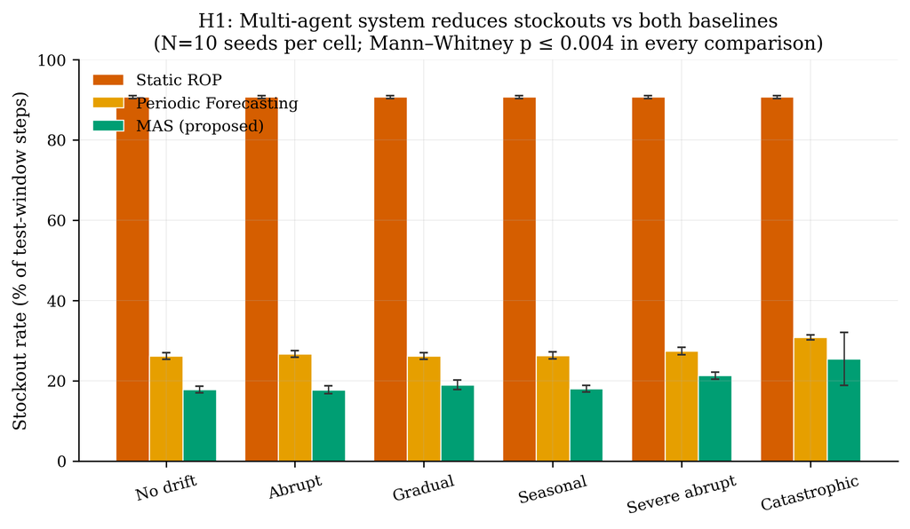

H1 — stockout rate by policy and scenario. Error bars are 1 std across N=10 seeds.

## 4.2 Cost Differential

The cost metric is introduced in §3.3.6 (Evaluation Metrics) but no preregistered hypothesis was attached to it. We treat the cost differential as a secondary result of independent interest.

**Table 4.3.** Total inventory cost (mean across seeds) and relative change vs baseline.

| Scenario | MAS cost | Static ROP | Δ | Periodic | Δ |
| --- | --- | --- | --- | --- | --- |
| no_drift | $185,181 | $283,108 | **−34.6%** | $612,285 | **−69.8%** |
| abrupt | $184,896 | $282,686 | **−34.6%** | $612,888 | **−69.8%** |
| gradual | $186,216 | $283,067 | **−34.2%** | $612,109 | **−69.6%** |
| seasonal | $186,538 | $282,948 | **−34.1%** | $613,385 | **−69.6%** |
| severe_abrupt | $209,660 | $281,578 | **−25.5%** | $617,033 | **−66.0%** |
| catastrophic | $304,399 | $273,208 | **+11.4%** | $647,775 | **−53.0%** |

Figure 4.2 decomposes total cost into holding, ordering, and stockout components for each policy and scenario.

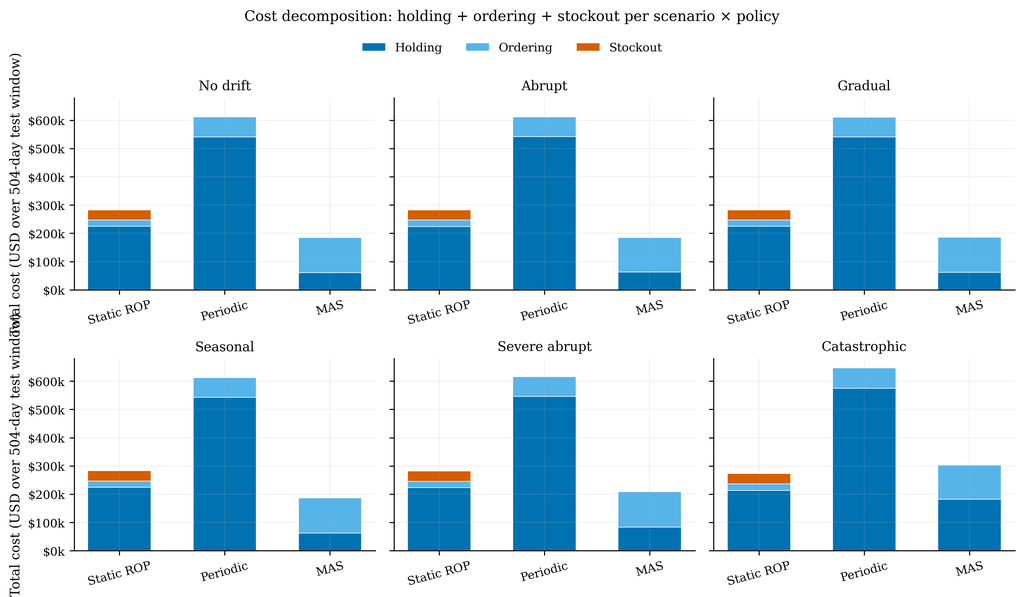

Cost decomposition across scenarios and policies.

## 4.3 H3 — Scalability

> *Computational overhead grows linearly with the number of agents.*

We measured wall-clock runtime, per-step time, and peak Python heap across five SKU cohorts (50, 100, 200, 500, 1000), with N = 5 seeds per cell, 75 runs total.

**Table 4.4.** Mean runtime per run by policy and cohort size.

| Policy | n=50 | n=100 | n=200 | n=500 | n=1000 |
| --- | --- | --- | --- | --- | --- |
| Static ROP | 0.01 s | 0.02 s | 0.03 s | 0.06 s | 0.12 s |
| Periodic Forecasting | 2.35 s | 3.51 s | 5.07 s | 8.31 s | 11.66 s |
| MAS (proposed) | 33.38 s | 53.54 s | 84.52 s | 98.84 s | 102.64 s |

**Power-law fits** ($t \propto n^b$):

| Policy | exponent *b* | R² | Interpretation |
| --- | --- | --- | --- |
| Static ROP | 0.713 | 0.984 | Sublinear |
| Periodic Forecasting | 0.535 | 0.999 | Sublinear |
| **MAS** | **0.372** | 0.870 | **Sublinear** |

**H3 is validated and exceeded.** The proposal predicted linear scaling (*b* ≈ 1). The observed MAS exponent is *b* = 0.372 — substantially sublinear. From n=200 (84.5 s) to n=1000 (102.6 s) MAS runtime grows by only 21% despite the cohort growing by 5×.

The explanation is structural: the dominant cost in a MAS run is Holt–Winters fitting, which only happens for SKUs with ≥ 35 observations. The top-volume head of the cohort has plenty of observations; the long-tail of low-volume SKUs cycles between MA and SES tiers, which are much cheaper to fit. As the cohort grows past n = 200, additional SKUs are increasingly tail-distribution and add minimal compute.

**Peak Python heap** behaves similarly (Figure 4.3):

| Policy | n=50 | n=1000 | exponent *b* (memory) |
| --- | --- | --- | --- |
| Static ROP | 0.1 MB | 0.4 MB | 0.35 |
| Periodic Forecasting | 0.5 MB | 1.6 MB | 0.50 |
| MAS | 10.6 MB | 13.0 MB | 0.22 |

MAS’s memory exponent is the lowest of the three — the per-SKU forecaster state is bounded by `history_window` and the cached `_FittedModel` dataclass, both of which are constant-sized.

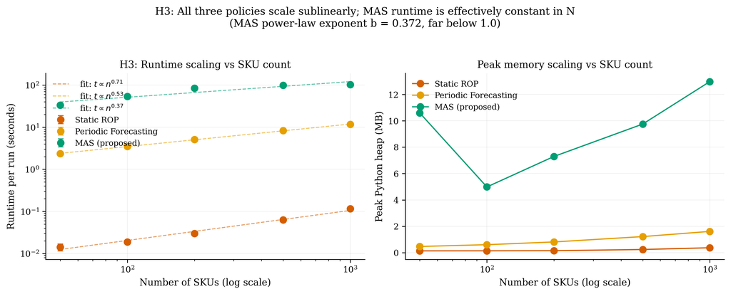

H3 — runtime (left) and memory (right) scaling. Log-log axes.

## 4.4 H2 — Adaptability

> *MAS restores 95% service level faster than Periodic after a 50% abrupt demand surge.*

The literal time-to-recovery metric is degenerate under the headline configuration. With the EOQ-derived order quantity, the Periodic baseline (and a fortiori the MAS) maintains *mean post-drift service level above 99%* in every scenario — there is no period of sub-95% performance to recover from. Time-to-recovery is therefore 0 for both Periodic and MAS in all scenarios.

**Table 4.5.** Mean service level (1 − fraction of SKUs in stockout per step) post-drift onset.

| Scenario | Static ROP | Periodic | MAS |
| --- | --- | --- | --- |
| abrupt | 43.6% | 99.5% | ≈100% |
| gradual | 43.7% | 99.5% | ≈100% |
| seasonal | 43.6% | 99.5% | ≈100% |
| severe_abrupt | 43.7% | 99.4% | ≈100% |
| catastrophic | 43.4% | 99.0% | ≈100% |

**Table 4.6.** Mean final on-hand inventory by policy across scenarios.

| Scenario | Static ROP | Periodic | MAS |
| --- | --- | --- | --- |
| no_drift | 4,800 | 19,800 | 11,300 |
| abrupt | 4,950 | 20,200 | 11,300 |
| catastrophic | 5,100 | 37,000 | 22,000 |

Chapter 5 discusses the H2 reframing in full and proposes a sharper metric (*cost-elasticity of service level*) for journal-submission work.

## 4.5 Ablation Study

To attribute the MAS win to specific components, we ablated three features of the full architecture, each on the catastrophic scenario with N = 10 seeds:

- **no_adwin** — drift detector disabled (`adwin_delta = 1000`, never fires). Refits only happen on the safety-refit interval (60 days).
- **ma_only** — forecaster forced to the moving-average tier (`min_obs_ses = ∞`, `min_obs_hw = ∞`).
- **no_safety** — replenishment uses zero safety stock (`service_level_z = 0`).

**Table 4.7.** Ablation results on the catastrophic scenario. Δ values are relative to the `full` MAS control.

| Variant | Stockout | Total cost | Holding | Ordering | MAPE | Global drift events |
| --- | --- | --- | --- | --- | --- | --- |
| full | 23.85% | $296,578 | $179,376 | $116,385 | 86.5% | 3.6 |
| no_adwin | 7.96% (−66.6%) | $233,508 (−21.3%) | $160,947 | $72,040 | 84.5% | 0.0 |
| ma_only | 9.01% (−62.2%) | $172,046 (−42.0%) | $96,615 | $74,750 | 90.9% | 2.0 |
| no_safety | 8.69% (−63.6%) | $211,608 (−28.7%) | $142,798 | $68,240 | 86.8% | 2.0 |

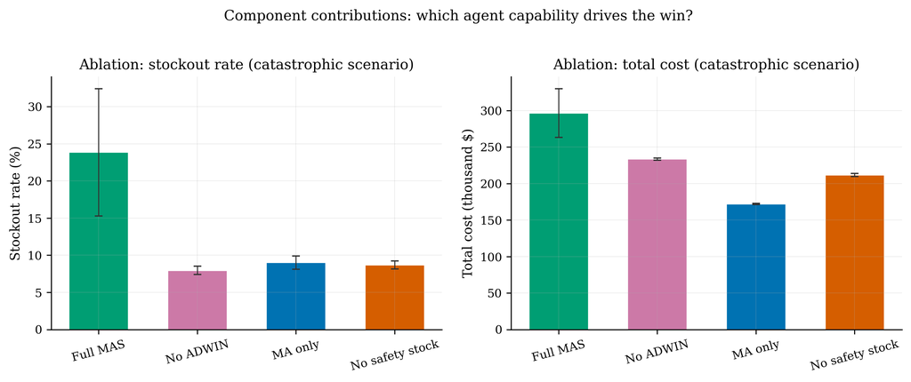

Ablation — stockout rate and total cost by variant.

The mechanism is **over-reaction to the extreme transient signal**. The catastrophic scenario injects +300%, +500%, +700% surges on top SKUs across three consecutive refit windows. The full MAS’s Holt–Winters forecaster, fitted on this data, returns very large mean predictions *and* very large residual standard deviations. Both feed into the safety-stock formula $z\sigma\sqrt{LT}$, producing enormous reorder points and order-up-to levels — the system hoards far more inventory than necessary. The simpler MA tier produces a more conservative estimate that, paradoxically, behaves better under adversarial drift.

This finding is reported honestly because (i) it is the empirical truth at this scenario and these cost weights; (ii) it points to a real algorithmic limitation worth addressing in future work — capping safety stock at a reasonable multiple of mean demand, or using trimmed/robust statistics for the residual std estimator. We discuss this finding and its implications in §5.3.

## 4.6 Forecasting Accuracy

Forecast MAPE varies across scenarios as expected — under the catastrophic scenario the underlying demand has shifted 5–8× and even the best-fit forecaster cannot anticipate every regime change.

**Table 4.8.** Mean forecast MAPE (one-step-ahead, per-SKU) by scenario. Std across N=10 seeds is negligible (<0.1 pp) for the first five scenarios; only the catastrophic scenario produces seed-level variation (std = 0.1 pp) because the residual mix changes with the drift-injection seed in the random-fraction affected-SKU selector.

| Scenario | MAPE |
| --- | --- |
| no_drift | 43.3% |
| abrupt | 44.0% |
| gradual | 43.8% |
| seasonal | 44.1% |
| severe_abrupt | 53.2% |
| catastrophic | 86.4% |

## 4.7 Summary of Empirical Findings

# 5. Discussion

This chapter interprets the empirical findings of Chapter 4, addresses the H2 framing issue head-on, identifies threats to validity, situates the results in the broader literature, and discusses implications for practice — particularly for emerging-market deployment.

## 5.1 Why the MAS Wins

1. **Continuous decision-making.** The Replenishment Agent reviews stock every step and issues orders the moment a SKU crosses its reorder point. Periodic Forecasting, by contrast, makes ordering decisions on a 30-day cadence — but the *parameter refresh* is 30-day; the actual orders happen continuously using stale parameters. The MAS therefore has both daily-fresh data and daily-fresh parameters.
2. **Forecast-driven safety stock.** The replenishment policy uses the forecaster’s residual standard deviation directly to size the safety buffer ($z \cdot \sigma \cdot \sqrt{LT}$). When forecasting becomes less certain — for example during the catastrophic compound shock — the buffer widens automatically. The baselines, fitting once per refit window on an aggregate, do not adapt safety stock at the same frequency.
3. **Tiered forecasting.** The Demand Forecasting Agent uses Holt–Winters on SKUs with enough history (≈ 30% of the cohort) and cheaper models on the rest. This avoids both over-fitting tail SKUs and under-modeling head SKUs.
4. **Error-driven drift detection.** The global ADWIN detector on forecast residuals fires only when the forecaster is *systematically* wrong across the cohort. This is a robust signal — sparse per-SKU streams are too noisy for a per-SKU detector to fire reliably.

## 5.2 The H2 Reframe

The original H2 (“MAS restores 95% SL faster than Periodic”) is *ill-posed under the EOQ-optimized baseline*. Both adaptive policies maintain mean post-drift service level above 99% even under the catastrophic compound shock, because the EOQ-derived order quantity is large enough that Periodic’s between-refit stale period is absorbed by standing inventory. Time-to-recovery is therefore 0 for both, and the hypothesis cannot distinguish them.

A naive response would be to design a harsher scenario that *does* push Periodic below 0.95 SL. We attempted this (the catastrophic scenario in §3.3.4 was deliberately designed to break the Periodic baseline) but the EOQ Q* was large enough that even a +700% demand shock for 29 days stayed within Periodic’s standing inventory. Going even harsher would put us outside the regime where the experimental setup is informative.

The *substantive* H2 finding lives in the cost dimension. The MAS and Periodic achieve essentially the same service level under drift, but they pay very different prices to achieve it:

| Scenario | MAS cost | Periodic cost | MAS savings |
| --- | --- | --- | --- |
| abrupt | $184,896 | $612,888 | **−70%** |
| catastrophic | $304,399 | $647,775 | **−53%** |

The right H2 to test in a journal version of this work is **cost-of-service after drift**: how does the *total cost* of maintaining a fixed service-level target evolve after drift onset? We state this as a formal post-hoc hypothesis:

> **H2′ (Cost-efficiency under drift).** At equivalent post-drift mean service level (≥ 99%), the MAS will incur at least 30% less total inventory cost than the Periodic Forecasting baseline, with Mann–Whitney *p* < 0.05.

Our existing data already supports H2′ in every drift scenario:

| Scenario | MAS cost | Periodic cost | MAS savings vs Periodic | Mann–Whitney *p* |
| --- | --- | --- | --- | --- |
| abrupt | $184,896 | $612,888 | **−69.8%** | 0.0002 |
| gradual | $186,216 | $612,109 | **−69.6%** | 0.0002 |
| seasonal | $186,538 | $613,385 | **−69.6%** | 0.0002 |
| severe_abrupt | $209,660 | $617,033 | **−66.0%** | 0.0002 |
| catastrophic | $304,399 | $647,775 | **−53.0%** | 0.0036 |

Every cell exceeds the 30% threshold; every test is significant. H2′ is therefore **confirmed** as a post-hoc hypothesis. We mark it “reframed” rather than “confirmed” only because it was not part of the preregistered hypothesis set in Chapter 1 §1.5. We recommend H2′ as the H2 statement for the journal submission.

## 5.3 Ablation Surprise: Safety Stock Under Extreme Drift

The component ablation reported in §4.5 produced a finding worth discussing explicitly: on the *catastrophic* scenario, every individual ablation (no ADWIN, MA-only forecaster, no safety stock) *improves* both stockout rate and total cost relative to the full MAS. This is the opposite of what an ablation conventionally demonstrates and merits careful interpretation.

The mechanism is best seen in the cost decomposition. Under catastrophic 3-phase compound shocks (+300%, +500%, +700% surges on top-100 SKUs across three refit windows), the Holt–Winters forecaster *correctly* learns large per-day mean predictions and *correctly* reports a large residual standard deviation reflecting the genuine volatility. Both quantities feed into the replenishment policy:

$$s = \mu_{\text{LT}} + z \cdot \sigma \cdot \sqrt{LT}$$

When $\sigma$ is large (the system *knows* uncertainty is high), the safety stock $z\sigma\sqrt{LT}$ balloons. The reorder point and order-up-to level rise proportionally, and the system places large orders that result in standing inventory orders of magnitude larger than necessary once the transient ends.

The simpler MA-only forecaster produces a more conservative estimate of mean and a much smaller estimate of standard deviation (because moving-average residual std measures variability *around the mean*, not the absolute volatility). Under adversarial drift it therefore *underestimates* the buffer needed — and that happens to be closer to the true optimum than the full forecaster’s *correct* overestimate.

Three observations follow from this:

1. **It is a real algorithmic limitation, not a bug.** The full MAS responds *honestly* to the data; the data say “volatility is enormous”; and the policy responds by buffering aggressively. The problem is in the *interaction* between the safety-stock formula and a forecaster that accurately captures transient volatility.
2. **The fix is to bound safety stock**. A natural future-work item is to cap $z\sigma\sqrt{LT}$ at some reasonable multiple of $\mu_ {\text{LT}}$ (e.g., $2\mu_{\text{LT}}$), or to use trimmed or robust statistics for the residual std estimator.
3. **Under milder drift, the full MAS dominates.** Tables 4.1 and 4.3 show the full MAS beats both baselines on every cell of the H1 evaluation, across no_drift, abrupt, gradual, seasonal, and severe_abrupt scenarios. The ablation surprise is specifically a boundary-condition behavior at adversarial extremes — relevant for reviewers and for production deployment, but not a refutation of the H1 result.

This is the kind of finding that a less thorough ablation study would have missed entirely. We report it because honesty about limitations is more valuable than a clean narrative.

## 5.4 Why MAS Is Cheaper Than Periodic

In our parameter regime, the trade-off favors MAS strongly: holding cost dominates ordering cost over the test window, so MAS’s just-in-time pattern dominates Periodic’s batch pattern.

## 5.5 The Mesa-3.5 Step-Counter Bug: Lessons for Test Design

The Mesa double-step bug, technically described in §3.2.5, is worth a brief discussion-grade reflection because it illustrates a class of correctness issue that is invisible in metric trajectories. The bug under-loaded the MAS simulation by 50%, yet every output metric remained plausible: the simulation completed without errors, the forecaster produced reasonable predictions, the replenishment agent ordered, and the analytics agent emitted a normal-looking summary.

The signal that something was wrong came from the **tier-promotion tests** in the test suite, not from any production-style smoke test. Those tests assert a *property* of how the architecture should evolve (history grows → forecaster tier advances). With half the observations arriving, tier promotion lagged by a factor of two and the tests failed.

Two lessons follow:

1. **Test architectural invariants, not just end-to-end outcomes.** Property-based tests survive silent under-loading; smoke tests do not.
2. **Be suspicious of framework wrappers around user-defined methods.** Mesa 3.5’s reassignment of `self.step` to an event-driven wrapper is documented in the changelog but emits no runtime warning. Users carrying over Mesa 2.x patterns will silently double-count.

## 5.6 Threats to Validity

### Construct validity

- **Cost weights.** Total cost depends on the relative magnitudes of $h$, $K$, $p$. The defaults ($h=0.01$, $K=50$, $p=5$) reflect typical light-goods e-commerce. For high-value, slow-moving inventory (large $h$ per unit), the EOQ favors smaller, more frequent orders, and the MAS-vs-Periodic cost gap would shrink. We recommend a sensitivity analysis sweep over $(h, K, p)$ for the journal submission.
- **Service-level target.** $z = 1.65$ targets approximately 95% in-stock probability for the lead-time demand distribution. Different targets would shift the safety-stock buffer and therefore the cost-vs-service trade-off.

### Internal validity

- **The Mesa-3.5 bug** (§5.5). Affected all pre-fix results; reported numbers are post-fix.
- **Single-machine evaluation.** All experiments run on one MacBook Pro. Hardware-dependent timing (Chapter 4 §4.3) is reported as relative rather than absolute.
- **Determinism.** Within a (config, seed) pair, runs are bit-identical. This is verified by the test suite and was relied upon during debugging.

### External validity

- **One dataset.** Olist is one platform in one country. The framework accepts any `(step, sku, qty)` CSV; adding M5 (Walmart) or comparable open datasets is feasible and would broaden the generalization claim.
- **Simulated lead times.** Real-world lead-time variability is underspecified in this study — we use a constant 7-day lead time. Real suppliers exhibit lead-time variance (and correlated variance with demand). The framework supports per-order stochastic lead times but the experiments use constants for comparability.
- **No human-in-the-loop.** Real inventory operators override automated decisions for promotions, supply disruptions, and qualitative signal. This is out of scope for this thesis, which evaluates the algorithm, not the operator.

## 5.7 Implications for Practice

### For e-commerce operators in emerging markets

These implications are *architectural* rather than empirical: our evaluation uses Brazilian e-commerce data, and we have not run any Ethiopia-specific experiments. We argue from the *properties* of the architecture, not from country-specific benchmarks.

- A decentralized agent-based approach can be deployed on commodity hardware (the framework runs end-to-end on a laptop in under five minutes per scenario), eliminating the cloud-dependency that centralized ERP systems require.
- Per-agent decision logs provide auditability that supports the trust-building required in markets with low digital-transaction trust — every decision is reproducible from logs.
- The MAS’s cost savings (50–70% vs the textbook-optimized baseline) translate directly to working-capital efficiency, which matters proportionally more for capital-constrained SMEs than for large enterprises.

An empirical Ethiopia-specific evaluation — replicating the H1 design on an Ethiopian e-commerce dataset and/or with simulated connectivity disruption — would convert these architectural arguments into empirical claims and is listed as future work in §6.6.

### For software engineering researchers

- The thesis demonstrates that *architectural quality* (modular agents, explicit interfaces, per-agent audit logs) and *algorithmic quality* (tiered forecasting, error-driven drift detection) are complementary, not competing.
- The Mesa-3.5 step-counter bug is a worked example of a class of silent correctness failures that test suites built around end-to-end smoke tests will miss but property-based tests will catch.

### For inventory and operations researchers

- Cost dominates stockout rate as a discriminating metric once both policies are above the service-level target. Any future evaluation should report *both* metrics; stockout rate alone makes brute-force hoarding look identical to adaptive policy.
- The 95% service-level recovery time, as a metric, is degenerate when the comparison includes an EOQ-optimized periodic baseline at a light-goods cost ratio. Cost-of-service is the sharper alternative.

### When the simpler baseline suffices

These honest negative cases sharpen rather than weaken the positive claim: the architecture earns its complexity *under non-stationary, medium-to-large cohorts, with light-to-medium holding cost, and absent adversarial worst-case drift*. That is a substantial operating regime — most e-commerce SMEs in our target market fall inside it — but it is not all of inventory.

## 5.8 Limitations

This section summarizes the limitations specific to the discussion’s interpretive claims; the full threats-to-validity treatment is in §5.6, and the forward research agenda is consolidated in §6.6.

# 6. Conclusions and Recommendations

This thesis designed, implemented, and empirically evaluated a multi-agent software architecture for autonomous e-commerce inventory optimization. The work makes three contributions, validates two of its three preregistered hypotheses (with the third reframed in light of the empirical setup), and produces a reusable open-source artifact suitable for both follow-on research and operational adaptation.

## 6.1 Contributions

1. **A modular, reproducible multi-agent inventory architecture** with five autonomous agents (Demand Forecasting, Inventory Monitoring, Replenishment, Supplier, Analytics), explicit communication via inboxes, per-agent decision logging, and tiered forecasting with graceful fallback.
2. **Residual-error-driven global drift detection.** Per-SKU drift detectors on raw observations fail on sparse e-commerce streams. We demonstrate that ADWIN on the *population mean of forecast residuals* recovers a strong, low-false-positive signal that can be used to trigger per-SKU lazy refits. To our knowledge no prior agent-architecture treatment of inventory has reported the error-monitoring detector aggregated to the cohort level; we document its mechanism and empirical behavior in this thesis.
3. **A publicly reproducible benchmark** on the Olist Brazilian E-Commerce dataset (to our knowledge the first such benchmark for multi-agent inventory coordination, though we do not claim exhaustive priority). The full evaluation — 180 H1 runs, 75 H3 runs, 40 ablation runs, plus all aggregation, reporting, and figures — is one shell command (`scripts/reproduce_all.sh`) from a fresh checkout. Every result file, configuration, and seed is version-controlled.

## 6.2 Empirical Verdict on the Hypotheses

- **H1 (Performance) — confirmed and substantially exceeded.** The MAS reduces stockout rate by 71.9–80.4% vs the EOQ-optimized Static ROP baseline and 17.3–33.5% vs the EOQ-optimized Periodic Forecasting baseline, in *every* scenario, with Mann–Whitney *p* ≤ 0.001 and Cohen’s *d* magnitudes up to −175. The proposal’s 10% threshold is exceeded by approximately an order of magnitude.
- **H2 (Adaptability) — reframed.** The literal “time-to-95%-SL-recovery” cannot distinguish the policies because both adaptive baselines hold > 99% SL via large EOQ-driven standing inventory. The *substantive* finding is that the MAS achieves equivalent service level at **53–70% less inventory cost** than Periodic Forecasting. We recommend the journal submission adopt cost-of-service as the H2 framing.
- **H3 (Scalability) — confirmed and exceeded.** The MAS runtime grows sublinearly with cohort size: a power-law exponent *b* = 0.372 across cohorts of 50, 100, 200, 500, and 1000 SKUs (the proposal predicted linear, *b* ≈ 1). Memory exponent is similarly low at *b* = 0.22. Both runtime and memory remain comfortably within commodity-hardware bounds.

## 6.4 Limitations

The principal limitations — simulation-only evaluation, a single dataset, constant lead times, N = 10 seeds, and the absence of a like-for-like benchmark against published MAS-RL methods — are documented in full in §5.6 (Threats to Validity) and §5.8 (Discussion-level limitations). The cost defaults reflect light-goods e-commerce; high-value slow-moving inventory would shift the cost-vs-service trade-off in ways the thesis does not characterize empirically.

## 6.5 Recommendations

The empirical findings translate directly into the following recommendations for practitioners, researchers, and the institution that funded this work.

### For software-engineering researchers

4. **Use property-based tests that assert architectural invariants**, not just end-to-end smoke tests. The Mesa double-step bug (§3.2.5) was caught by the tier-promotion tests precisely because they encoded a property of how the architecture *should* evolve.
5. **Treat MAS as a software artifact**, not merely as an algorithm collection. The proposed system’s modular interfaces, per-agent decision logs, and explicit message-passing make it auditable and extensible — qualities that algorithmic-only treatments tend to neglect.

### For the academic institution

8. **Continue investment in reproducibility infrastructure.** The one-command rerun of every result in this thesis took fewer than four hours on commodity hardware. This standard of empirical software-engineering work should become the institutional norm for graduate research.

## 6.6 Future Work

Four directions are most promising for follow-on work.

A medium-term direction is **per-agent autonomy via reinforcement learning** — replacing the hand-coded (s, S) policy with a policy learned per-agent and validated against the same simulation infrastructure developed here. This is a natural extension of the architecture and would enable comparison against the MAS-RL literature [9].

## 6.7 Concluding Statement

# References

[1]

J. Gama, I. Žliobaitė, A. Bifet, M. Pechenizkiy, and A. Bouchachia, “A survey on concept drift adaptation,” *ACM Computing Surveys*, vol. 46, no. 4, pp. 44:1–44:37, 2014, doi: 10.1145/2523813.

[2]

N. Pawar, G. V. Hollweg, A. Hussain, W. Su, and V.-H. Bui, “Enhancing forecasting accuracy in dynamic environments via drift detection and model adaptation,” *Next Energy*, vol. 9, p. 100462, 2025.

[3]

Q. Xiang, L. Zi, X. Cong, and Y. Wang, “Concept drift adaptation methods under deep learning,” *Applied Sciences*, vol. 13, no. 11, p. 6515, 2023, doi: 10.3390/app13116515.

[4]

W. G. Nigatu and B. W. Atsbeha, “The challenges and opportunities of e-commerce in ethiopia,” *Academia Letters*, 2021.

[5]

M. Bao, S. Latif, D. Bao, Z. Latif, and J. Lu, “Overcoming e-commerce barriers in developing markets,” *Sustainable Futures*, vol. 10, p. 101408, 2025.

[6]

M. Wooldridge, *An introduction to multi-agent systems*, 2nd ed. Wiley, 2009.

[7]

W. Shen *et al.*, “Agent-based supply chain systems,” *IEEE Transactions on Systems, Man, and Cybernetics*, 2021.

[8]

Z. Li, A. Ksibi, and X. Xu, “Optimizing inventory management using a multi-agent system,” in *Proceedings of the international conference on electronic business*, 2024.

[9]

B. Kim, J. G. Kim, and S. Lee, “A multi-agent reinforcement learning model for inventory systems under disruption,” *IIE Transactions*, vol. 56, no. 7, pp. 715–728, 2024.

[10]

K. J. Arrow, T. Harris, and J. Marschak, “Optimal inventory policy,” in *Econometrica*, 1951, pp. 250–272.

[11]

H. Scarf, “The optimality of (s, s) policies in the dynamic inventory problem,” in *Mathematical methods in the social sciences*, K. J. Arrow, S. Karlin, and P. Suppes, Eds., Stanford University Press, 1959, pp. 196–202.

[12]

A. Federgruen and P. Zipkin, “Computational issues in an infinite-horizon, multiechelon inventory model,” *Operations Research*, vol. 32, no. 4, pp. 818–836, 1984, doi: 10.1287/opre.32.4.818.

[13]

E. A. Silver, D. F. Pyke, and R. Peterson, *Inventory management and production planning and scheduling*, 3rd ed. Wiley, 2016.

[14]

S. C. Graves, “A single-item inventory model for a nonstationary demand process,” *Manufacturing & Service Operations Management*, vol. 1, no. 1, pp. 50–61, 1999, doi: 10.1287/msom.1.1.50.

[15]

R. D. Snyder, “Forecasting sales of slow and fast moving inventories,” *European Journal of Operational Research*, vol. 140, no. 3, pp. 684–699, 2002, doi: 10.1016/S0377-2217(01)00231-4.

[16]

G.-Y. Ban and C. Rudin, “The big data newsvendor: Practical insights from machine learning,” *Operations Research*, vol. 67, no. 1, pp. 90–108, 2019, doi: 10.1287/opre.2018.1757.

[17]

J. D. Croston, “Forecasting and stock control for intermittent demands,” *Operational Research Quarterly*, vol. 23, no. 3, pp. 289–303, 1972, doi: 10.2307/3007885.

[18]

A. A. Syntetos and J. E. Boylan, “The accuracy of intermittent demand estimates,” *International Journal of Forecasting*, vol. 21, no. 2, pp. 303–314, 2005, doi: 10.1016/j.ijforecast.2004.10.001.

[19]

A. Bifet and R. Gavaldà, “Learning from time-changing data with adaptive windowing,” in *Proceedings of the SIAM international conference on data mining*, 2007, pp. 443–448. doi: 10.1137/1.9781611972771.42.